# (Dataset Exploration of Ford Gobike Data)

## Preliminary Wrangling

> the trip data of the ford gobike 2018.

```python
# import all packages and set plots to be embedded inline
import numpy as np
import pandas as pd
import matplotlib.pyplot as plt
import seaborn as sb

%matplotlib inline
import warnings
warnings.simplefilter("ignore")
```

> Load in your dataset and describe its properties through the questions below. Try and motivate your exploration goals through this section.

```python
df = pd.read_csv('201806-fordgobike-tripdata.csv')
df.head()
```

|  | duration_sec | start_time | end_time | start_station_id | start_station_name | start_station_latitude | start_station_longitude | end_station_id | end_station_name | end_station_latitude | end_station_longitude | bike_id | user_type | bike_share_for_all_trip |
| --- | --- | --- | --- | --- | --- | --- | --- | --- | --- | --- | --- | --- | --- | --- |
| 0 | 59088 | 2018-06-30 23:32:44.6590 | 2018-07-01 15:57:33.3160 | 76.0 | McCoppin St at Valencia St | 37.771662 | -122.422423 | 95.0 | Sanchez St at 15th St | 37.766219 | -122.431060 | 2100 | Subscriber | Yes |
| 1 | 60358 | 2018-06-30 21:48:19.5570 | 2018-07-01 14:34:18.1000 | 248.0 | Telegraph Ave at Ashby Ave | 37.855956 | -122.259795 | 239.0 | Bancroft Way at Telegraph Ave | 37.868813 | -122.258764 | 653 | Customer | No |
| 2 | 63654 | 2018-06-30 20:26:53.0310 | 2018-07-01 14:07:47.2320 | 23.0 | The Embarcadero at Steuart St | 37.791464 | -122.391034 | 50.0 | 2nd St at Townsend St | 37.780526 | -122.390288 | 3235 | Subscriber | No |
| 3 | 50508 | 2018-06-30 20:29:59.8130 | 2018-07-01 10:31:48.2500 | 58.0 | Market St at 10th St | 37.776619 | -122.417385 | 88.0 | 11th St at Bryant St | 37.770030 | -122.411726 | 3675 | Subscriber | No |
| 4 | 51697 | 2018-06-30 18:24:56.6960 | 2018-07-01 08:46:33.7390 | 196.0 | Grand Ave at Perkins St | 37.808894 | -122.256460 | 272.0 | Woolsey St at Sacramento St | 37.850578 | -122.278175 | 3232 | Customer | No |

```python
df.info()
```

```
<class 'pandas.core.frame.DataFrame'>
RangeIndex: 195968 entries, 0 to 195967
Data columns (total 14 columns):
duration_sec               195968 non-null int64
start_time                 195968 non-null object
end_time                   195968 non-null object
start_station_id           193907 non-null float64
start_station_name         193907 non-null object
start_station_latitude     195968 non-null float64
start_station_longitude    195968 non-null float64
end_station_id             193907 non-null float64
end_station_name           193907 non-null object
end_station_latitude       195968 non-null float64
end_station_longitude      195968 non-null float64
bike_id                    195968 non-null int64
user_type                  195968 non-null object
bike_share_for_all_trip    195968 non-null object
dtypes: float64(6), int64(2), object(6)
memory usage: 20.9+ MB
```

```python
df.describe()
```

|  | duration_sec | start_station_id | start_station_latitude | start_station_longitude | end_station_id | end_station_latitude | end_station_longitude | bike_id |
| --- | --- | --- | --- | --- | --- | --- | --- | --- |
| count | 195968.000000 | 193907.00000 | 195968.000000 | 195968.000000 | 193907.000000 | 195968.000000 | 195968.000000 | 195968.000000 |
| mean | 907.748439 | 115.48563 | 37.770014 | -122.351045 | 114.370678 | 37.770142 | -122.350611 | 2294.684581 |
| std | 2642.666562 | 96.49233 | 0.103552 | 0.299995 | 96.697389 | 0.103473 | 0.299821 | 1241.622764 |
| min | 61.000000 | 3.00000 | 37.312854 | -122.444293 | 3.000000 | 37.312854 | -122.444293 | 11.000000 |
| 25% | 351.000000 | 30.00000 | 37.771058 | -122.411403 | 30.000000 | 37.771431 | -122.410345 | 1237.000000 |
| 50% | 564.000000 | 86.00000 | 37.781074 | -122.397380 | 85.000000 | 37.781270 | -122.397086 | 2401.000000 |
| 75% | 896.000000 | 181.00000 | 37.797280 | -122.289370 | 181.000000 | 37.797280 | -122.290230 | 3388.000000 |
| max | 85278.000000 | 356.00000 | 45.510000 | -73.570000 | 356.000000 | 45.510000 | -73.570000 | 4307.000000 |

```python
df.isnull().sum()
```

```
duration_sec                  0
start_time                    0
end_time                      0
start_station_id           2061
start_station_name         2061
start_station_latitude        0
start_station_longitude       0
end_station_id             2061
end_station_name           2061
end_station_latitude          0
end_station_longitude         0
bike_id                       0
user_type                     0
bike_share_for_all_trip       0
dtype: int64
```

```python
df_new = df[df['start_station_id'].isnull() == False]
df_new.info()
```

```
<class 'pandas.core.frame.DataFrame'>
Int64Index: 193907 entries, 0 to 195967
Data columns (total 14 columns):
duration_sec               193907 non-null int64
start_time                 193907 non-null object
end_time                   193907 non-null object
start_station_id           193907 non-null float64
start_station_name         193907 non-null object
start_station_latitude     193907 non-null float64
start_station_longitude    193907 non-null float64
end_station_id             193907 non-null float64
end_station_name           193907 non-null object
end_station_latitude       193907 non-null float64
end_station_longitude      193907 non-null float64
bike_id                    193907 non-null int64
user_type                  193907 non-null object
bike_share_for_all_trip    193907 non-null object
dtypes: float64(6), int64(2), object(6)
memory usage: 22.2+ MB
```

```python
df_new.isnull().sum()
```

```
duration_sec               0
start_time                 0
end_time                   0
start_station_id           0
start_station_name         0
start_station_latitude     0
start_station_longitude    0
end_station_id             0
end_station_name           0
end_station_latitude       0
end_station_longitude      0
bike_id                    0
user_type                  0
bike_share_for_all_trip    0
dtype: int64
```

```python
df_new.duplicated().sum()
```

```
0
```

```python
df_new.info()
```

```
<class 'pandas.core.frame.DataFrame'>
Int64Index: 193907 entries, 0 to 195967
Data columns (total 14 columns):
duration_sec               193907 non-null int64
start_time                 193907 non-null object
end_time                   193907 non-null object
start_station_id           193907 non-null float64
start_station_name         193907 non-null object
start_station_latitude     193907 non-null float64
start_station_longitude    193907 non-null float64
end_station_id             193907 non-null float64
end_station_name           193907 non-null object
end_station_latitude       193907 non-null float64
end_station_longitude      193907 non-null float64
bike_id                    193907 non-null int64
user_type                  193907 non-null object
bike_share_for_all_trip    193907 non-null object
dtypes: float64(6), int64(2), object(6)
memory usage: 22.2+ MB
```

```python
df_new.start_time = pd.to_datetime(df_new.start_time)
df_new.end_time = pd.to_datetime(df_new.end_time)
```

```python
df_new.info()
```

```
<class 'pandas.core.frame.DataFrame'>
Int64Index: 193907 entries, 0 to 195967
Data columns (total 14 columns):
duration_sec               193907 non-null int64
start_time                 193907 non-null datetime64[ns]
end_time                   193907 non-null datetime64[ns]
start_station_id           193907 non-null float64
start_station_name         193907 non-null object
start_station_latitude     193907 non-null float64
start_station_longitude    193907 non-null float64
end_station_id             193907 non-null float64
end_station_name           193907 non-null object
end_station_latitude       193907 non-null float64
end_station_longitude      193907 non-null float64
bike_id                    193907 non-null int64
user_type                  193907 non-null object
bike_share_for_all_trip    193907 non-null object
dtypes: datetime64[ns](2), float64(6), int64(2), object(4)
memory usage: 22.2+ MB
```

```python
df_new['duration_min'] = df_new['duration_sec'] / 60
```

```python
df_new['start_time_month_name']=df_new['start_time'].dt.strftime('%B')

# extract start time month number
df_new['start_time_month']=df_new['start_time'].dt.month.astype(int)

# extract start time weekdays
df_new['start_time_weekday']=df_new['start_time'].dt.strftime('%a')

# extract start time day
df_new['start_time_day']=df_new['start_time'].dt.day.astype(int)

# extract start time hour
df_new['start_time_hour']=df_new['start_time'].dt.hour
df_new.info()
```

```
<class 'pandas.core.frame.DataFrame'>
Int64Index: 193907 entries, 0 to 195967
Data columns (total 20 columns):
duration_sec               193907 non-null int64
start_time                 193907 non-null datetime64[ns]
end_time                   193907 non-null datetime64[ns]
start_station_id           193907 non-null float64
start_station_name         193907 non-null object
start_station_latitude     193907 non-null float64
start_station_longitude    193907 non-null float64
end_station_id             193907 non-null float64
end_station_name           193907 non-null object
end_station_latitude       193907 non-null float64
end_station_longitude      193907 non-null float64
bike_id                    193907 non-null int64
user_type                  193907 non-null object
bike_share_for_all_trip    193907 non-null object
duration_min               193907 non-null float64
start_time_month_name      193907 non-null object
start_time_month           193907 non-null int32
start_time_weekday         193907 non-null object
start_time_day             193907 non-null int32
start_time_hour            193907 non-null int64
dtypes: datetime64[ns](2), float64(7), int32(2), int64(3), object(6)
memory usage: 29.6+ MB
```

```python
df_new.info()
```

```
<class 'pandas.core.frame.DataFrame'>
Int64Index: 193907 entries, 0 to 195967
Data columns (total 20 columns):
duration_sec               193907 non-null int64
start_time                 193907 non-null datetime64[ns]
end_time                   193907 non-null datetime64[ns]
start_station_id           193907 non-null float64
start_station_name         193907 non-null object
start_station_latitude     193907 non-null float64
start_station_longitude    193907 non-null float64
end_station_id             193907 non-null float64
end_station_name           193907 non-null object
end_station_latitude       193907 non-null float64
end_station_longitude      193907 non-null float64
bike_id                    193907 non-null int64
user_type                  193907 non-null object
bike_share_for_all_trip    193907 non-null object
duration_min               193907 non-null float64
start_time_month_name      193907 non-null object
start_time_month           193907 non-null int32
start_time_weekday         193907 non-null object
start_time_day             193907 non-null int32
start_time_hour            193907 non-null int64
dtypes: datetime64[ns](2), float64(7), int32(2), int64(3), object(6)
memory usage: 29.6+ MB
```

### What is the structure of your dataset?

> There are 193907 about trips for fordgobike in the dataset with (duration_sec, start_time, end_time, start_station_id, start_station_name, start_station_latitude, start_station_longitude, end_station_id, end_station_name, end_station_latitude ,end_station_longitude, bike_id, user_type, bike_share_for_all_trip). Most variables are numerical, and 4 object others are 2 datetime, .

### What is/are the main feature(s) of interest in your dataset?

> im inersted in what the behavior of the users of bike how daily they active.

### What features in the dataset do you think will help support your investigation into your feature(s) of interest?

> the duration of the trip and the daily usage of bikes will me to gain insights

## Univariate Exploration

> In this section, investigate distributions of individual variables. If you see unusual points or outliers, take a deeper look to clean things up and prepare yourself to look at relationships between variables.

```python
df_new.info()
```

```
<class 'pandas.core.frame.DataFrame'>
Int64Index: 193907 entries, 0 to 195967
Data columns (total 20 columns):
duration_sec               193907 non-null int64
start_time                 193907 non-null datetime64[ns]
end_time                   193907 non-null datetime64[ns]
start_station_id           193907 non-null float64
start_station_name         193907 non-null object
start_station_latitude     193907 non-null float64
start_station_longitude    193907 non-null float64
end_station_id             193907 non-null float64
end_station_name           193907 non-null object
end_station_latitude       193907 non-null float64
end_station_longitude      193907 non-null float64
bike_id                    193907 non-null int64
user_type                  193907 non-null object
bike_share_for_all_trip    193907 non-null object
duration_min               193907 non-null float64
start_time_month_name      193907 non-null object
start_time_month           193907 non-null int32
start_time_weekday         193907 non-null object
start_time_day             193907 non-null int32
start_time_hour            193907 non-null int64
dtypes: datetime64[ns](2), float64(7), int32(2), int64(3), object(6)
memory usage: 29.6+ MB
```

> Make sure that, after every plot or related series of plots, that you include a Markdown cell with comments about what you observed, and what you plan on investigating next.

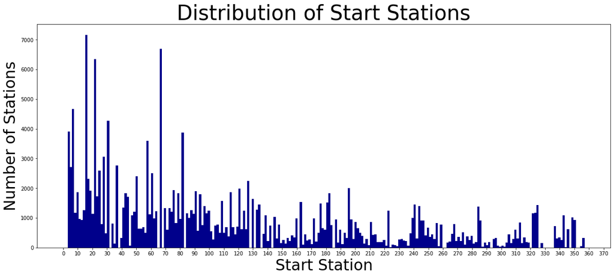

```python
# Plotting start station id distribution on a standard scale
binsize = 1.5
bins = np.arange(0, df_new['start_station_id'].astype(float).max()+binsize, binsize)

plt.figure(figsize=[20, 8])
plt.xticks(range(0, 402, 10))
plt.hist(data = df_new, x = 'start_station_id', bins = bins, color='darkblue')
plt.title('Distribution of Start Stations',size= 40)
plt.xlabel('Start Station',size = 30)
plt.ylabel('Number of Stations',size = 30)
plt.show()
```

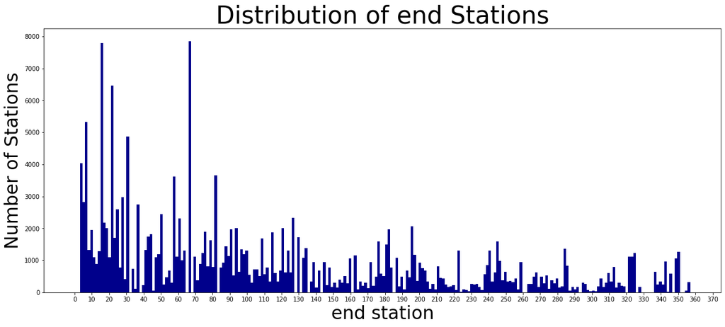

```python
binsize = 1.5
bins = np.arange(0, df_new['end_station_id'].astype(float).max()+binsize, binsize)

plt.figure(figsize=[20, 8])
plt.xticks(range(0, 402, 10))
plt.hist(data = df_new, x = 'end_station_id', bins = bins, color='darkblue')
plt.title('Distribution of end Stations',size= 40)
plt.xlabel('end station',size = 30)
plt.ylabel('Number of Stations',size = 30)
plt.show()
```

#### last 2 graphs are comparing the 2 stations

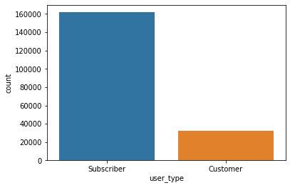

```python
sb.countplot(data = df_new, x = 'user_type');
```

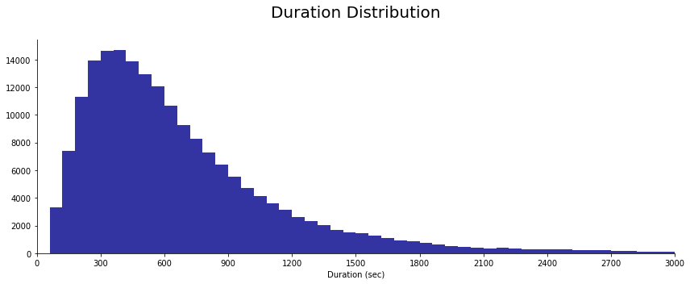

```python
binsize = 60
bins = np.arange(0, df_new['duration_sec'].max()+binsize, binsize)
# Plotting
fig, axes = plt.subplots(figsize = (12,5))
plt.hist(df_new.duration_sec, bins = bins, color='darkblue', alpha=0.8);

# Aesthetic wrangling
plt.xticks(ticks = [x for x in range(0,3600,300)])
plt.title('Duration Distribution\n', size=20)
plt.xlabel('Duration (sec)')
plt.xlim(0,3000)
sb.despine(fig)
plt.tight_layout();
```

#### this paragraph show us trips time

### Discuss the distribution(s) of your variable(s) of interest. Were there any unusual points? Did you need to perform any transformations?

the start stations and end stations are same.

### Of the features you investigated, were there any unusual distributions? Did you perform any operations on the data to tidy, adjust, or change the form of the data? If so, why did you do this?

> the number of subscribers is way more than costmurs

## Bivariate Exploration

> In this section, investigate relationships between pairs of variables in your data. Make sure the variables that you cover here have been introduced in some fashion in the previous section (univariate exploration).

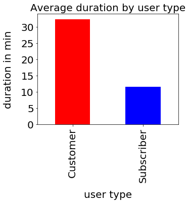

```python
new_color=['red', 'blue']
ax = df_new.groupby('user_type')['duration_min'].mean().plot(kind='bar', color=new_color, figsize=(5,4),fontsize=20)
ax.set_title('Average duration by user type', fontsize=20, y=1)
ax.set_ylabel('duration in min', labelpad=15,fontsize=20)
ax.set_xlabel('user type', labelpad=15,fontsize=20)
```

#### the trip duration of customers is approximatly 30 minutes , on the other hand subscribers is around 12 mintues

```python
df_new.info()
```

```
<class 'pandas.core.frame.DataFrame'>
Int64Index: 193907 entries, 0 to 195967
Data columns (total 20 columns):
duration_sec               193907 non-null int64
start_time                 193907 non-null datetime64[ns]
end_time                   193907 non-null datetime64[ns]
start_station_id           193907 non-null float64
start_station_name         193907 non-null object
start_station_latitude     193907 non-null float64
start_station_longitude    193907 non-null float64
end_station_id             193907 non-null float64
end_station_name           193907 non-null object
end_station_latitude       193907 non-null float64
end_station_longitude      193907 non-null float64
bike_id                    193907 non-null int64
user_type                  193907 non-null object
bike_share_for_all_trip    193907 non-null object
duration_min               193907 non-null float64
start_time_month_name      193907 non-null object
start_time_month           193907 non-null int32
start_time_weekday         193907 non-null object
start_time_day             193907 non-null int32
start_time_hour            193907 non-null int64
dtypes: datetime64[ns](2), float64(7), int32(2), int64(3), object(6)
memory usage: 34.6+ MB
```

```python
# calculating % split for the user type
customer = df_new.query('user_type == "Customer"')['bike_id'].count()
subscriber = df_new.query('user_type == "Subscriber"')['bike_id'].count()

customer_proportion = customer / df_new['bike_id'].count()
subscriber_proportion = subscriber / df_new['bike_id'].count()
```

[output not shown]

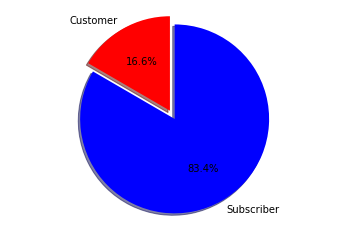

```python
labels = ['Customer', 'Subscriber']
sizes = [customer_proportion, subscriber_proportion]
colors = ['red', 'blue']
explode = (0, 0.1)

plt.pie(sizes, explode=explode, labels=labels, colors = colors,
        autopct='%1.1f%%', shadow=True, startangle=90)
plt.axis('equal')
```

#### number of subscribers more than customers

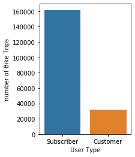

```python
plt.subplot(1, 2, 1)

g = sb.countplot(data=df_new, x="user_type", order=df_new.user_type.value_counts().index)
g.set_xlabel('User Type')
g.set_ylabel('number of Bike Trips')
```

#### also the number of trips of subscribers is more

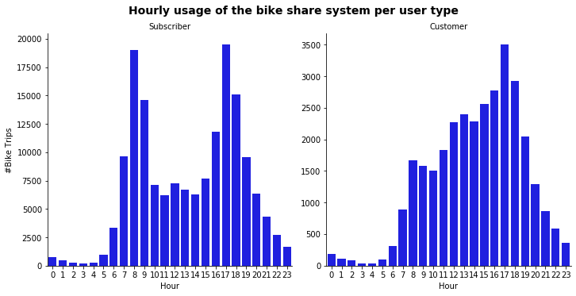

```python
g = sb.catplot(data=df_new, x='start_time_hour', col="user_type", kind='count', sharey = False,
            color = 'blue')
g.set_axis_labels("Hour", "#Bike Trips")
g.set_titles("{col_name}")
g.fig.suptitle('Hourly usage of the bike share system per user type', y=1.03, fontsize=14, fontweight='bold');
```

### Did you observe any interesting relationships between the other features (not the main feature(s) of interest)?

> the trips duration of subscirbers is less than customers. thats why I conclude that they use for work.

## Multivariate Exploration

> Create plots of three or more variables to investigate your data even further. Make sure that your investigations are justified, and follow from your work in the previous sections.

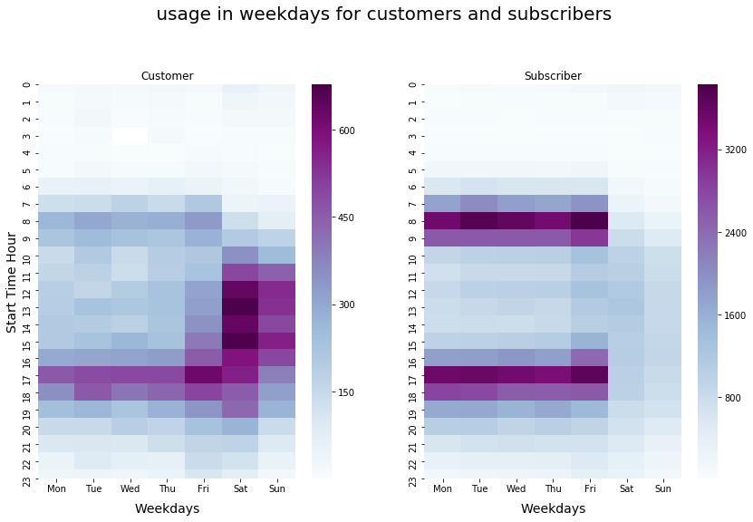

```python
df_new['start_time_weekday'] = pd.Categorical(df_new['start_time_weekday'],
                                                categories=['Mon','Tue','Wed','Thu','Fri','Sat', 'Sun'],
                                                ordered=True)
plt.figure(figsize=(14,8))
plt.suptitle(' usage in weekdays for customers and subscribers', fontsize=20, y=1.03)


plt.subplot(1, 2, 1)

df_customer = df_new.query('user_type == "Customer"').groupby(["start_time_hour", "start_time_weekday"])["bike_id"].size().reset_index()
df_customer = df_customer.pivot("start_time_hour", "start_time_weekday", "bike_id")
sb.heatmap(df_customer, cmap="BuPu",fmt='d')

plt.title("Customer", y=1.015)
plt.xlabel('Weekdays',fontsize=14, labelpad=10)
plt.ylabel('Start Time Hour',fontsize=14)

plt.subplot(1, 2, 2)
df_subscriber = df_new.query('user_type == "Subscriber"').groupby(["start_time_hour", "start_time_weekday"])["bike_id"].size().reset_index()
df_subscriber = df_subscriber.pivot("start_time_hour", "start_time_weekday", "bike_id")
sb.heatmap(df_subscriber, cmap="BuPu",fmt='d')

plt.title("Subscriber", y=1.015)
plt.xlabel('Weekdays',fontsize=14, labelpad=10)
plt.ylabel('');
```

```python
df_new.info()
```

```
<class 'pandas.core.frame.DataFrame'>
Int64Index: 193907 entries, 0 to 195967
Data columns (total 20 columns):
duration_sec               193907 non-null int64
start_time                 193907 non-null datetime64[ns]
end_time                   193907 non-null datetime64[ns]
start_station_id           193907 non-null float64
start_station_name         193907 non-null object
start_station_latitude     193907 non-null float64
start_station_longitude    193907 non-null float64
end_station_id             193907 non-null float64
end_station_name           193907 non-null object
end_station_latitude       193907 non-null float64
end_station_longitude      193907 non-null float64
bike_id                    193907 non-null int64
user_type                  193907 non-null object
bike_share_for_all_trip    193907 non-null object
duration_min               193907 non-null float64
start_time_month_name      193907 non-null object
start_time_month           193907 non-null int32
start_time_weekday         193907 non-null category
start_time_day             193907 non-null int32
start_time_hour            193907 non-null int64
dtypes: category(1), datetime64[ns](2), float64(7), int32(2), int64(3), object(5)
memory usage: 33.3+ MB
```

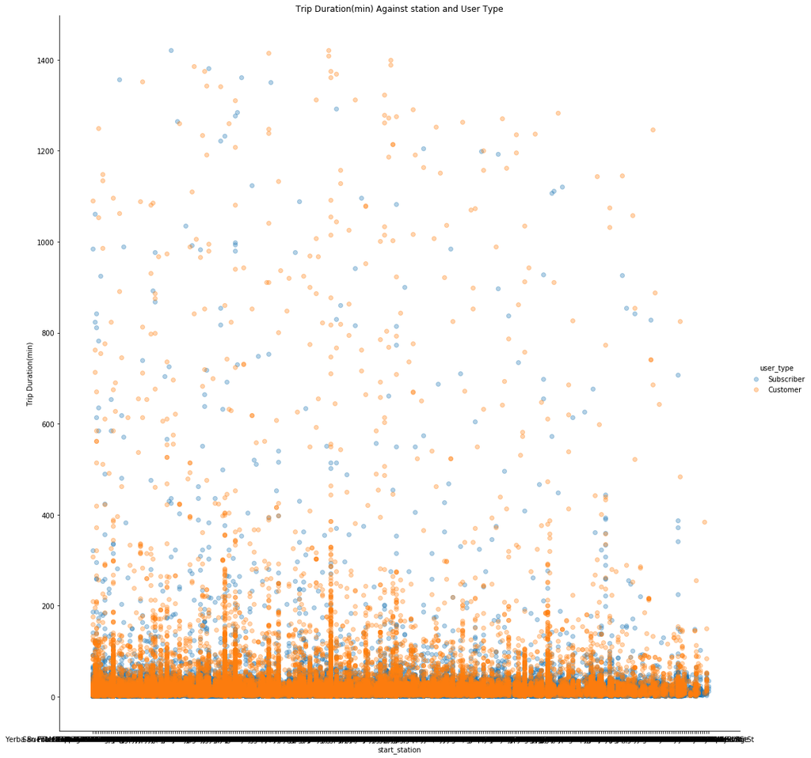

```python
g = sb.FacetGrid(data =  df_new, hue = 'user_type', height = 15)
g.map(plt.scatter, 'start_station_name','duration_min', alpha = 1/3)
g.add_legend()
plt.title('Trip Duration(min) Against station and User Type')
plt.xlabel('start_station')
plt.ylabel('Trip Duration(min)');
```

> i thought that there strong relation between the duration of trip and user type.

> At the end of your report, make sure that you export the notebook as an html file from the `File > Download as... > HTML` menu. Make sure you keep track of where the exported file goes, so you can put it in the same folder as this notebook for project submission. Also, make sure you remove all of the quote-formatted guide notes like this one before you finish your report!

```python
df_new.info()
```

```
<class 'pandas.core.frame.DataFrame'>
Int64Index: 193907 entries, 0 to 195967
Data columns (total 20 columns):
duration_sec               193907 non-null int64
start_time                 193907 non-null datetime64[ns]
end_time                   193907 non-null datetime64[ns]
start_station_id           193907 non-null float64
start_station_name         193907 non-null object
start_station_latitude     193907 non-null float64
start_station_longitude    193907 non-null float64
end_station_id             193907 non-null float64
end_station_name           193907 non-null object
end_station_latitude       193907 non-null float64
end_station_longitude      193907 non-null float64
bike_id                    193907 non-null int64
user_type                  193907 non-null object
bike_share_for_all_trip    193907 non-null object
duration_min               193907 non-null float64
start_time_month_name      193907 non-null object
start_time_month           193907 non-null int32
start_time_weekday         193907 non-null category
start_time_day             193907 non-null int32
start_time_hour            193907 non-null int64
dtypes: category(1), datetime64[ns](2), float64(7), int32(2), int64(3), object(5)
memory usage: 33.3+ MB
```

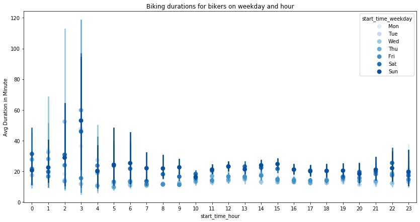

```python
fig = plt.figure(figsize = [14,7])
ax = sb.pointplot(data = df_new, x = 'start_time_hour', y = 'duration_min', hue = 'start_time_weekday', linestyles = '',palette = 'Blues');
plt.title('Biking durations for bikers on weekday and hour');
plt.ylabel('Avg Duration in Minute');
```

#### bikers on sat and sun bike more

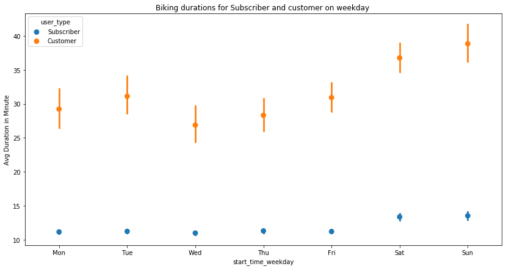

```python
fig = plt.figure(figsize = [14,7])
sb.pointplot(data=df_new, x='start_time_weekday', y='duration_min', hue='user_type',linestyles="");
plt.title('Biking durations for Subscriber and customer on weekday ');
plt.xlabel('start_time_weekday');
plt.ylabel('Avg Duration in Minute');
```

```python
df_new.to_csv('df_new.csv')
```

#### customer usage is flactuted while subscirbers is more consistant ,also this grahp shows that both of them their usage increase in weekend(Sat and sun)